# Assignment #1 - Data Set Selection and Initial Processing

Gerd Bizi

2024-02-21

# Background

In the BCB420H1 course, my first assignment was to analyze an RNASeq dataset of particular interest to me. The first phase of this overarching project was to first pick the dataset, and to then perform the initial pre-processing, including normalization of the data, along with mapping our genes to their corresponding HUGO symbols.

## Why is this dataset of interest to you?

I chose to work with the GSE205517 dataset since it tied with my part-time research I did last summer. My project, which admittedly didn’t go as far as I’d hoped, was to look at regulators for key proteins involved in the differentiation process of induced pluripotent stem cells into ventricular cardiomyocytes. The interest here was that if several regulators were identified, this could be used to temporally upregulate these regulators to more efficiently induce differentiation into cardiomyocytes for patient use. Unfortunately, time commitments and other plans derailed the project, but it left me still wanting to explore it, and perhaps return to my PI with a new lead on the project. Perhaps this course could serve as a springboard for that!

Without any further ado, let’s begin our analysis!

## Loading in Libraries

Here we will load in the libraries we will be using for our analysis.

# Retrieving our Data from the GEO

First, we will retrieve our dataset from the Gene Expression Omnibus (GEO). We must notice that the dataset we selected was a SuperSeries. Therefore, we are going to load in two different datasets from the GEO and then combine them

```r
# GEO Accession numbers
geo_acc_1 <- "GSE203375"
geo_acc_2 <- "GSE204885"

# The filenames for saving/loading data
filename_1 <- paste0(geo_acc_1, ".RData")
filename_2 <- paste0(geo_acc_2, ".RData")

# Reading in files from the GEO or locally
if (!file.exists(filename_1)) {
  gset_1 <- getGEO(geo_acc_1, GSEMatrix=TRUE, getGPL=FALSE)
  saveRDS(gset_1, filename_1)
} else {
  gset_1 <- readRDS(filename_1)
}
gset_1 <- gset_1[[1]]

if (!file.exists(filename_2)) {
  gset_2 <- getGEO(geo_acc_2, GSEMatrix=TRUE, getGPL=FALSE)
  saveRDS(gset_2, filename_2)
} else {
  gset_2 <- readRDS(filename_2)
}
gset_2 <- gset_2[[1]]
```

We now have our data loaded in. We now need to retrieve the counts tables from the GEO.

```r
# load counts table from GEO
urld <- "https://www.ncbi.nlm.nih.gov/geo/download/?format=file&type=rnaseq_counts"
path_1 <- paste(urld, paste0("acc=", geo_acc_1), paste0("file=", geo_acc_1, "_raw_counts_GRCh38.p13_NCBI.tsv.gz"), sep="&");
path_2 <- paste(urld, paste0("acc=", geo_acc_2), paste0("file=", geo_acc_2, "_raw_counts_GRCh38.p13_NCBI.tsv.gz"), sep="&");

if (!file.exists(paste0(geo_acc_1,"_raw_counts.RData"))) {
  counts_data_1 <- as.matrix(data.table::fread(path_1, header=T, colClasses="integer"), rownames=1)
  name_mapping <- setNames(gset_1@phenoData@data[["title"]], gset_1@phenoData@data[["geo_accession"]])
  colnames(counts_data_1) <- name_mapping[colnames(counts_data_1)]
  saveRDS(counts_data, paste0(geo_acc_1, "_raw_counts.RData"))
} else {
  counts_data_1 <- readRDS(paste0(geo_acc_1, "_raw_counts.RData"))
}

if (!file.exists(paste0(geo_acc_2,"_raw_counts.RData"))) {
  counts_data_2 <- as.matrix(data.table::fread(path_2, header=T, colClasses="integer"), rownames=1)
  name_mapping <- setNames(gset_2@phenoData@data[["title"]], gset_2@phenoData@data[["geo_accession"]])
  colnames(counts_data_2) <- name_mapping[colnames(counts_data_2)]
  saveRDS(counts_data_2, paste0(geo_acc_2, "_raw_counts.RData"))
} else {
  counts_data_2 <- readRDS(paste0(geo_acc_2, "_raw_counts.RData"))
}

counts_data <- cbind(counts_data_1, counts_data_2) # combine matrices into one
```

# Briefly Explaining our Dataset

```r
gset_1@experimentData@title # study title
```

```
## [1] "Bulk RNA-seq of a time series of hPSCs as they differentiate towards left ventricle cardiomyocytes"
```

```r
gset_1@experimentData@abstract # study abstract
```

```
## [1] "We report that both hESCs and hiPSCs can be differentiated towrads left ventricle cardiomyocytes using an optimised protocol and that these cells transit via first heart field progenitors."
```

```r
gset_1@experimentData@other$overall_design # summary of experiment
```

```
## [1] "Examination of the transcriptome of two hPSC lines as they differentiate towards left ventricle cardiomyocytes; critical time points were collected"
```

```r
unique(gset_1@phenoData@data[["extract_protocol_ch1.1"]]) # platform
```

```
## [1] "KAPA mRNA (polyA) HyperPrep"
```

```r
unique(gset_1@phenoData@data[["experiment number:ch1"]]) # heart
```

```
## [1] "h28" "h30" "h32" "h41" "h18" "h42"
```

```r
unique(gset_1@phenoData@data[["cell_line:ch1"]]) # cell lines
```

```
## [1] "H9"    "MLC2V"
```

```r
unique(gset_1@phenoData@data[["day:ch1"]]) # day of differentiation
```

```
## [1] "0"  "2"  "4"  "10" "15" "20" "40" "60" "6"
```

```r
gset_1@experimentData@other$platform_id # GPL id
```

```
## [1] "GPL20301"
```

```r
gset_1@experimentData@other$last_update_date # last update date
```

```
## [1] "Aug 08 2023"
```

```r
unique(gset_1@phenoData@data$organism_ch1) # organism
```

```
## [1] "Homo sapiens"
```

```r
gset_2@experimentData@title # study title
```

```
## [1] "Bulk-RNA-sequencing from chamber specific heart tissue and isolated cardiomyocytes"
```

```r
gset_2@experimentData@abstract # study abstract
```

```
## [1] "Healthy hearts from warm cadavers not usable for heart transplants were identified and tissues were isolated from these. From ventricle tissues, cardiomyocytes were further isolated. Bulk-RNA-sequencing was performed."
```

```r
gset_2@experimentData@other$overall_design # summary of experiment
```

```
## [1] "Bulk-RNA-sequencing from 3 different donors (tissue) and 3 other donors (isolated CMs)"
```

```r
unique(gset_2@phenoData@data[["extract_protocol_ch1.1"]]) # platform
```

```
## [1] "KAPA mRNA (polyA) HyperPrep"
```

```r
unique(gset_2@phenoData@data[["chamber:ch1"]]) # cell lines
```

```
## [1] "LV" "RV" "LA" "RA"
```

```r
unique(gset_2@phenoData@data[["patient:ch1"]]) # patient
```

```
## [1] "P1" "P2" "P3" "P4" "P5" "P6"
```

```r
unique(gset_2@phenoData@data[["tissue:ch1"]]) # tissue
```

```
## [1] "Ventricle Isolated Cells" "Heart tissue"
```

```r
gset_2@experimentData@other$platform_id # GPL id
```

```
## [1] "GPL20301"
```

```r
gset_2@experimentData@other$last_update_date # last update date
```

```
## [1] "Apr 26 2023"
```

```r
unique(gset_2@phenoData@data$organism_ch1) # organism
```

```
## [1] "Homo sapiens"
```

```r
sample_info_1 <- gset_1@phenoData@data[ , (ncol(gset_1@phenoData@data)-2):ncol(gset_1@phenoData@data)]
colnames(sample_info_1) <- gsub(":ch1", "", colnames(sample_info_1))
knitr::kable(sample_info_1, format = "pipe", caption = "<b>Table 1:</b> Sample information for Cardiomyocytes Derived from Stem Cells")
```

**Table 1:** Sample information for Cardiomyocytes Derived from Stem Cells

|  | cell_line | day | experiment number |
| --- | --- | --- | --- |
| GSM6170585 | H9 | 0 | h28 |
| GSM6170586 | H9 | 2 | h28 |
| GSM6170587 | H9 | 4 | h28 |
| GSM6170588 | H9 | 10 | h28 |
| GSM6170589 | H9 | 15 | h28 |
| GSM6170590 | H9 | 20 | h28 |
| GSM6170591 | H9 | 40 | h28 |
| GSM6170592 | H9 | 60 | h28 |
| GSM6170593 | H9 | 0 | h30 |
| GSM6170594 | H9 | 2 | h30 |
| GSM6170595 | H9 | 4 | h30 |
| GSM6170596 | H9 | 6 | h30 |
| GSM6170597 | H9 | 10 | h30 |
| GSM6170598 | H9 | 15 | h30 |
| GSM6170599 | H9 | 20 | h30 |
| GSM6170600 | H9 | 40 | h30 |
| GSM6170601 | H9 | 60 | h30 |
| GSM6170602 | H9 | 0 | h32 |
| GSM6170603 | H9 | 2 | h32 |
| GSM6170604 | H9 | 4 | h32 |
| GSM6170605 | H9 | 6 | h32 |
| GSM6170606 | H9 | 15 | h32 |
| GSM6170607 | H9 | 20 | h32 |
| GSM6170608 | H9 | 40 | h32 |
| GSM6170609 | H9 | 60 | h32 |
| GSM6170610 | H9 | 0 | h41 |
| GSM6170611 | H9 | 2 | h41 |
| GSM6170612 | H9 | 4 | h41 |
| GSM6170613 | H9 | 6 | h41 |
| GSM6170614 | H9 | 10 | h41 |
| GSM6170615 | H9 | 15 | h41 |
| GSM6170616 | H9 | 20 | h41 |
| GSM6170617 | H9 | 40 | h41 |
| GSM6170618 | MLC2V | 0 | h18 |
| GSM6170619 | MLC2V | 2 | h18 |
| GSM6170620 | MLC2V | 4 | h18 |
| GSM6170621 | MLC2V | 6 | h18 |
| GSM6170622 | MLC2V | 10 | h18 |
| GSM6170623 | MLC2V | 15 | h18 |
| GSM6170624 | MLC2V | 20 | h18 |
| GSM6170625 | MLC2V | 40 | h18 |
| GSM6170626 | MLC2V | 60 | h18 |
| GSM6170627 | MLC2V | 0 | h42 |
| GSM6170628 | MLC2V | 2 | h42 |
| GSM6170629 | MLC2V | 4 | h42 |
| GSM6170630 | MLC2V | 6 | h42 |
| GSM6170631 | MLC2V | 10 | h42 |
| GSM6170632 | MLC2V | 15 | h42 |
| GSM6170633 | MLC2V | 20 | h42 |
| GSM6170634 | MLC2V | 40 | h42 |
| GSM6170635 | MLC2V | 60 | h42 |

```r
sample_info_2 <- gset_2@phenoData@data[ , (ncol(gset_2@phenoData@data)-2):ncol(gset_2@phenoData@data)]
colnames(sample_info_2) <- gsub(":ch1", "", colnames(sample_info_2))
knitr::kable(sample_info_2, format = "pipe", caption = "<b>Table 2:</b> Sample information for Patient-Derived Samples")
```

**Table 2:** Sample information for Patient-Derived Samples

|  | chamber | patient | tissue |
| --- | --- | --- | --- |
| GSM6199297 | LV | P1 | Ventricle Isolated Cells |
| GSM6199298 | RV | P1 | Ventricle Isolated Cells |
| GSM6199299 | LV | P2 | Ventricle Isolated Cells |
| GSM6199300 | RV | P2 | Ventricle Isolated Cells |
| GSM6199301 | LV | P3 | Ventricle Isolated Cells |
| GSM6199302 | RV | P3 | Ventricle Isolated Cells |
| GSM6199303 | LA | P4 | Heart tissue |
| GSM6199304 | LV | P4 | Heart tissue |
| GSM6199305 | RA | P4 | Heart tissue |
| GSM6199306 | RV | P4 | Heart tissue |
| GSM6199307 | LA | P5 | Heart tissue |
| GSM6199308 | LV | P5 | Heart tissue |
| GSM6199309 | RA | P5 | Heart tissue |
| GSM6199310 | RV | P5 | Heart tissue |
| GSM6199311 | LA | P6 | Heart tissue |
| GSM6199312 | LV | P6 | Heart tissue |
| GSM6199313 | RA | P6 | Heart tissue |
| GSM6199314 | RV | P6 | Heart tissue |

# Calculating Overview Statistics

A good way to get an initial overview of our dataset is to calculate our overview stats. We will calculate those, and display them afterwards.

```r
overview_stats <- list()

for (sample_name in colnames(counts_data)) {
  sample_data <- counts_data[, sample_name]

  total_counts <- sum(sample_data)
  mean_counts <- mean(sample_data)
  median_counts <- median(sample_data)
  sd_counts <- sd(sample_data)
  var_counts <- var(sample_data)
  genes_detected <- sum(sample_data > 1) # Check binarily--if there's a number, a transcript of a gene was detected
  overview_stats[[sample_name]] <- c(total_counts, mean_counts, median_counts, sd_counts, var_counts, genes_detected)
}

overview_stats_df <- do.call(rbind, overview_stats)
rownames(overview_stats_df) <- names(overview_stats)
colnames(overview_stats_df) <- c("Total Counts", "Mean Counts", "Median Counts", "Counts Standard Deviation", "Counts Variation", "Genes Detected")

knitr::kable(overview_stats_df[, ], format = "pipe", caption = "<b>Table 3:</b> Overview Statistics of Samples, Pre-Processed")
```

**Table 3:** Overview Statistics of Samples, Pre-Processed

|  | Total Counts | Mean Counts | Median Counts | Counts Standard Deviation | Counts Variation | Genes Detected |
| --- | --- | --- | --- | --- | --- | --- |
| Heart 28 Day 0 H9 | 18453700 | 468.6535 | 2 | 5130.297 | 26319948 | 20244 |
| Heart 28 Day 2 H9 | 23870613 | 606.2224 | 3 | 3139.263 | 9854975 | 21592 |
| Heart 28 Day 4 H9 | 25318263 | 642.9872 | 5 | 2983.706 | 8902501 | 22660 |
| Heart 28 Day 10 H9 | 21851574 | 554.9465 | 4 | 4298.786 | 18479563 | 21742 |
| Heart 28 Day 15 H9 | 20986981 | 532.9892 | 6 | 3642.463 | 13267535 | 23027 |
| Heart 28 Day 20 H9 | 23259524 | 590.7031 | 3 | 5248.329 | 27544953 | 21652 |
| Heart 28 Day 40 H9 | 21937784 | 557.1359 | 3 | 4831.324 | 23341696 | 21224 |
| Heart 28 Day 60 H9 | 22253696 | 565.1589 | 4 | 3959.359 | 15676524 | 22133 |
| Heart 30 Day 0 H9 | 19283730 | 489.7331 | 3 | 3242.159 | 10511597 | 20970 |
| Heart 30 Day 2 H9 | 22871063 | 580.8376 | 4 | 3335.582 | 11126110 | 22242 |
| Heart 30 Day 4 H9 | 23869372 | 606.1909 | 5 | 3112.805 | 9689557 | 22531 |
| Heart 30 Day 6 H9 | 26021496 | 660.8466 | 4 | 4061.728 | 16497632 | 22352 |
| Heart 30 Day 10 H9 | 26550269 | 674.2754 | 5 | 4388.058 | 19255057 | 22864 |
| Heart 30 Day 15 H9 | 25252246 | 641.3106 | 4 | 6568.280 | 43142300 | 22036 |
| Heart 30 Day 20 H9 | 22491284 | 571.1927 | 2 | 4572.533 | 20908055 | 20786 |
| Heart 30 Day 40 H9 | 18068387 | 458.8680 | 2 | 5730.314 | 32836499 | 20389 |
| Heart 30 Day 60 H9 | 20354644 | 516.9302 | 3 | 5415.739 | 29330234 | 21630 |
| Heart 32 Day 0 H9 | 21955120 | 557.5762 | 3 | 2820.303 | 7954112 | 21484 |
| Heart 32 Day 2 H9 | 22322543 | 566.9073 | 3 | 2977.240 | 8863959 | 21453 |
| Heart 32 Day 4 H9 | 21069694 | 535.0898 | 4 | 2614.716 | 6836742 | 22298 |
| Heart 32 Day 6 H9 | 22119734 | 561.7568 | 4 | 3252.789 | 10580636 | 21933 |
| Heart 32 Day 15 H9 | 22444870 | 570.0140 | 4 | 4742.315 | 22489555 | 21922 |
| Heart 32 Day 20 H9 | 21442243 | 544.5511 | 4 | 4307.707 | 18556337 | 22456 |
| Heart 32 Day 40 H9 | 19921458 | 505.9289 | 4 | 3385.492 | 11461557 | 22096 |
| Heart 32 Day 60 H9 | 10766167 | 273.4195 | 0 | 5784.334 | 33458519 | 18474 |
| Heart 41 Day 0 H9 | 19904080 | 505.4876 | 3 | 2921.649 | 8536034 | 21645 |
| Heart 41 Day 2 H9 | 19601804 | 497.8110 | 3 | 3074.264 | 9451097 | 21415 |
| Heart 41 Day 4 H9 | 20276595 | 514.9481 | 4 | 3183.005 | 10131519 | 22194 |
| Heart 41 Day 6 H9 | 20519311 | 521.1121 | 4 | 3229.076 | 10426931 | 21832 |
| Heart 41 Day 10 H9 | 24418205 | 620.1291 | 4 | 6234.145 | 38864567 | 22050 |
| Heart 41 Day 15 H9 | 19787436 | 502.5253 | 2 | 5952.076 | 35427213 | 20754 |
| Heart 41 Day 20 H9 | 17909585 | 454.8351 | 3 | 3371.510 | 11367079 | 21710 |
| Heart 41 Day 40 H9 | 22219229 | 564.2835 | 4 | 3758.574 | 14126877 | 22220 |
| Heart 18 Day 0 MLC2V | 21960849 | 557.7217 | 3 | 2901.187 | 8416885 | 21351 |
| Heart 18 Day 2 MLC2V | 21086363 | 535.5131 | 4 | 3112.537 | 9687889 | 21926 |
| Heart 18 Day 4 MLC2V | 22191830 | 563.5877 | 4 | 3142.006 | 9872200 | 22264 |
| Heart 18 Day 6 MLC2V | 22699656 | 576.4846 | 4 | 3330.327 | 11091079 | 21892 |
| Heart 18 Day 10 MLC2V | 22087098 | 560.9279 | 5 | 4098.789 | 16800070 | 22531 |
| Heart 18 Day 15 MLC2V | 24443202 | 620.7640 | 5 | 4757.815 | 22636802 | 22704 |
| Heart 18 Day 20 MLC2V | 24405501 | 619.8065 | 3 | 4393.415 | 19302098 | 21466 |
| Heart 18 Day 40 MLC2V | 24209019 | 614.8166 | 3 | 6147.316 | 37789491 | 21549 |
| Heart 18 Day 60 MLC2V | 21330191 | 541.7054 | 3 | 6305.591 | 39760481 | 21440 |
| Heart 42 Day 0 MLC2V | 18295632 | 464.6392 | 3 | 2930.102 | 8585496 | 21047 |
| Heart 42 Day 2 MLC2V | 21064797 | 534.9654 | 3 | 3257.762 | 10613016 | 21399 |
| Heart 42 Day 4 MLC2V | 22884139 | 581.1697 | 5 | 3387.116 | 11472557 | 22702 |
| Heart 42 Day 6 MLC2V | 22487586 | 571.0988 | 4 | 3538.417 | 12520392 | 22067 |
| Heart 42 Day 10 MLC2V | 23907926 | 607.1700 | 4 | 4296.592 | 18460702 | 21926 |
| Heart 42 Day 15 MLC2V | 23903249 | 607.0512 | 5 | 4790.483 | 22948731 | 23029 |
| Heart 42 Day 20 MLC2V | 24539918 | 623.2202 | 4 | 4814.771 | 23182020 | 22120 |
| Heart 42 Day 40 MLC2V | 19799690 | 502.8365 | 3 | 5683.816 | 32305767 | 21359 |
| Heart 42 Day 60 MLC2V | 20951350 | 532.0843 | 3 | 6988.244 | 48835549 | 21614 |
| Patient 1 Left Ventricle Isolated Cells | 27562321 | 699.9777 | 3 | 17662.060 | 311948347 | 21155 |
| Patient 1 Right Ventricle Isolated cells | 27102792 | 688.3074 | 3 | 16262.413 | 264466075 | 21020 |
| Patient 2 Left Ventricle Isolated Cells | 26271923 | 667.2065 | 1 | 20501.205 | 420299396 | 19598 |
| Patient 2 Right Ventricle Isolated Cells | 26215323 | 665.7691 | 1 | 19137.790 | 366255024 | 19451 |
| Patient 3 Left Ventricle Isolated Cells | 25646577 | 651.3251 | 2 | 15323.497 | 234809551 | 20659 |
| Patient 3 Right Ventricle Isolated Cells | 25809297 | 655.4576 | 3 | 16315.152 | 266184194 | 21261 |
| Patient 4 Left Atria Tissue | 25437112 | 646.0055 | 6 | 13566.834 | 184058997 | 23608 |
| Patient 4 Left Ventricle Tissue | 25979258 | 659.7739 | 4 | 21529.885 | 463535946 | 22281 |
| Patient 4 Right Atria Tissue | 28828349 | 732.1300 | 6 | 15607.262 | 243586621 | 23755 |
| Patient 4 Right Ventricle Tissue | 24689138 | 627.0098 | 4 | 15712.600 | 246885803 | 22165 |
| Patient 5 Left Atria Tissue | 25382999 | 644.6312 | 5 | 14646.140 | 214509413 | 23008 |
| Patient 5 Left Ventricle Tissue | 23821125 | 604.9656 | 3 | 15547.763 | 241732925 | 21852 |
| Patient 5 Right Atria Tissue | 21814255 | 553.9988 | 5 | 14303.900 | 204601550 | 22925 |
| Patient 5 Right Ventricle Tissue | 23031675 | 584.9166 | 3 | 15553.495 | 241911211 | 21818 |
| Patient 6 Left Atria Tissue | 22048609 | 559.9505 | 4 | 13922.690 | 193841307 | 22440 |
| Patient 6 Left Ventricle Tissue | 25056697 | 636.3444 | 4 | 15271.709 | 233225097 | 22689 |
| Patient 6 Right Atria Tissue | 24879562 | 631.8458 | 5 | 13473.991 | 181548430 | 23301 |
| Patient 6 Right Ventricle Tissue | 25043289 | 636.0039 | 4 | 15289.542 | 233770094 | 22334 |

### Filtering Out Zero-Expressors

We saw that in our genes detected column that there were around 21,000 genes expressed with at least one transcript for each condition. This being the case, there are most likely genes that are not expressed through all the conditions, and can thus be filtered out. We can re-examine our overview stats again after doing this.

```r
rows_to_keep <- apply(counts_data, 1, function(row) any(row != 0))
counts_data_zero_filtered <- counts_data[rows_to_keep, ]

overview_stats_zero_filtered <- list()

for (sample_name in colnames(counts_data_zero_filtered)) {
  sample_data <- counts_data_zero_filtered[, sample_name]

  total_counts <- sum(sample_data)
  mean_counts <- mean(sample_data)
  median_counts <- median(sample_data)
  sd_counts <- sd(sample_data)
  var_counts <- var(sample_data)
  genes_detected <- sum(sample_data > 1) # Check binarily--if there's a number, a transcript of a gene was detected
  overview_stats_zero_filtered[[sample_name]] <- c(total_counts, mean_counts, median_counts, sd_counts, var_counts, genes_detected)
}

overview_stats_zero_filtered_df <- do.call(rbind, overview_stats_zero_filtered)
rownames(overview_stats_zero_filtered_df) <- names(overview_stats)
colnames(overview_stats_zero_filtered_df) <- c("Total Counts", "Mean Counts", "Median Counts", "Counts Standard Deviation", "Counts Variation", "Genes Detected")

knitr::kable(overview_stats_zero_filtered_df[, ], format = "pipe", caption = "<b>Table 4:</b> Overview Statistics After Eliminating Non-Expressed Genes")
```

**Table 4:** Overview Statistics After Eliminating Non-Expressed Genes

|  | Total Counts | Mean Counts | Median Counts | Counts Standard Deviation | Counts Variation | Genes Detected |
| --- | --- | --- | --- | --- | --- | --- |
| Heart 28 Day 0 H9 | 18453700 | 511.0696 | 4 | 5355.414 | 28680456 | 20244 |
| Heart 28 Day 2 H9 | 23870613 | 661.0893 | 7 | 3272.715 | 10710664 | 21592 |
| Heart 28 Day 4 H9 | 25318263 | 701.1815 | 9 | 3109.252 | 9667450 | 22660 |
| Heart 28 Day 10 H9 | 21851574 | 605.1726 | 7 | 4485.725 | 20121729 | 21742 |
| Heart 28 Day 15 H9 | 20986981 | 581.2280 | 11 | 3800.043 | 14440324 | 23027 |
| Heart 28 Day 20 H9 | 23259524 | 644.1654 | 6 | 5477.552 | 30003573 | 21652 |
| Heart 28 Day 40 H9 | 21937784 | 607.5602 | 6 | 5042.191 | 25423687 | 21224 |
| Heart 28 Day 60 H9 | 22253696 | 616.3093 | 8 | 4130.843 | 17063862 | 22133 |
| Heart 30 Day 0 H9 | 19283730 | 534.0570 | 5 | 3382.206 | 11439317 | 20970 |
| Heart 30 Day 2 H9 | 22871063 | 633.4071 | 8 | 3478.480 | 12099822 | 22242 |
| Heart 30 Day 4 H9 | 23869372 | 661.0549 | 9 | 3245.039 | 10530278 | 22531 |
| Heart 30 Day 6 H9 | 26021496 | 720.6574 | 9 | 4236.474 | 17947708 | 22352 |
| Heart 30 Day 10 H9 | 26550269 | 735.3016 | 11 | 4577.438 | 20952934 | 22864 |
| Heart 30 Day 15 H9 | 25252246 | 699.3532 | 8 | 6856.126 | 47006463 | 22036 |
| Heart 30 Day 20 H9 | 22491284 | 622.8892 | 5 | 4771.605 | 22768215 | 20786 |
| Heart 30 Day 40 H9 | 18068387 | 500.3984 | 4 | 5982.283 | 35787707 | 20389 |
| Heart 30 Day 60 H9 | 20354644 | 563.7156 | 6 | 5653.185 | 31958502 | 21630 |
| Heart 32 Day 0 H9 | 21955120 | 608.0403 | 6 | 2939.956 | 8643344 | 21484 |
| Heart 32 Day 2 H9 | 22322543 | 618.2160 | 6 | 3103.950 | 9634504 | 21453 |
| Heart 32 Day 4 H9 | 21069694 | 583.5187 | 8 | 2725.301 | 7427267 | 22298 |
| Heart 32 Day 6 H9 | 22119734 | 612.5993 | 7 | 3392.216 | 11507130 | 21933 |
| Heart 32 Day 15 H9 | 22444870 | 621.6038 | 7 | 4949.039 | 24492988 | 21922 |
| Heart 32 Day 20 H9 | 21442243 | 593.8364 | 8 | 4495.173 | 20206580 | 22456 |
| Heart 32 Day 40 H9 | 19921458 | 551.7187 | 8 | 3531.808 | 12473665 | 22096 |
| Heart 32 Day 60 H9 | 10766167 | 298.1657 | 2 | 6039.820 | 36479429 | 18474 |
| Heart 41 Day 0 H9 | 19904080 | 551.2374 | 7 | 3046.867 | 9283400 | 21645 |
| Heart 41 Day 2 H9 | 19601804 | 542.8660 | 6 | 3206.563 | 10282044 | 21415 |
| Heart 41 Day 4 H9 | 20276595 | 561.5541 | 8 | 3319.991 | 11022337 | 22194 |
| Heart 41 Day 6 H9 | 20519311 | 568.2760 | 7 | 3368.064 | 11343857 | 21832 |
| Heart 41 Day 10 H9 | 24418205 | 676.2547 | 8 | 6507.242 | 42344194 | 22050 |
| Heart 41 Day 15 H9 | 19787436 | 548.0070 | 5 | 6213.595 | 38608761 | 20754 |
| Heart 41 Day 20 H9 | 17909585 | 496.0005 | 7 | 3517.880 | 12375481 | 21710 |
| Heart 41 Day 40 H9 | 22219229 | 615.3547 | 8 | 3920.976 | 15374056 | 22220 |
| Heart 18 Day 0 MLC2V | 21960849 | 608.1990 | 6 | 3024.564 | 9147986 | 21351 |
| Heart 18 Day 2 MLC2V | 21086363 | 583.9804 | 7 | 3245.986 | 10536423 | 21926 |
| Heart 18 Day 4 MLC2V | 22191830 | 614.5959 | 9 | 3276.335 | 10734371 | 22264 |
| Heart 18 Day 6 MLC2V | 22699656 | 628.6600 | 7 | 3473.056 | 12062117 | 21892 |
| Heart 18 Day 10 MLC2V | 22087098 | 611.6954 | 9 | 4276.631 | 18289569 | 22531 |
| Heart 18 Day 15 MLC2V | 24443202 | 676.9470 | 10 | 4964.635 | 24647597 | 22704 |
| Heart 18 Day 20 MLC2V | 24405501 | 675.9029 | 6 | 4583.797 | 21011191 | 21466 |
| Heart 18 Day 40 MLC2V | 24209019 | 670.4614 | 7 | 6416.577 | 41172463 | 21549 |
| Heart 18 Day 60 MLC2V | 21330191 | 590.7331 | 6 | 6582.567 | 43330190 | 21440 |
| Heart 42 Day 0 MLC2V | 18295632 | 506.6919 | 5 | 3056.346 | 9341251 | 21047 |
| Heart 42 Day 2 MLC2V | 21064797 | 583.3831 | 6 | 3397.843 | 11545340 | 21399 |
| Heart 42 Day 4 MLC2V | 22884139 | 633.7692 | 9 | 3532.363 | 12477587 | 22702 |
| Heart 42 Day 6 MLC2V | 22487586 | 622.7868 | 8 | 3690.719 | 13621405 | 22067 |
| Heart 42 Day 10 MLC2V | 23907926 | 662.1227 | 8 | 4482.764 | 20095170 | 21926 |
| Heart 42 Day 15 MLC2V | 23903249 | 661.9932 | 11 | 4998.942 | 24989420 | 23029 |
| Heart 42 Day 20 MLC2V | 24539918 | 679.6255 | 8 | 5024.128 | 25241861 | 22120 |
| Heart 42 Day 40 MLC2V | 19799690 | 548.3463 | 6 | 5933.360 | 35204766 | 21359 |
| Heart 42 Day 60 MLC2V | 20951350 | 580.2412 | 6 | 7295.728 | 53227651 | 21614 |
| Patient 1 Left Ventricle Isolated Cells | 27562321 | 763.3300 | 5 | 18442.723 | 340134046 | 21155 |
| Patient 1 Right Ventricle Isolated cells | 27102792 | 750.6035 | 5 | 16981.043 | 288355813 | 21020 |
| Patient 2 Left Ventricle Isolated Cells | 26271923 | 727.5929 | 3 | 21407.855 | 458296238 | 19598 |
| Patient 2 Right Ventricle Isolated Cells | 26215323 | 726.0253 | 3 | 19984.008 | 399360566 | 19451 |
| Patient 3 Left Ventricle Isolated Cells | 25646577 | 710.2741 | 4 | 16000.625 | 256020003 | 20659 |
| Patient 3 Right Ventricle Isolated Cells | 25809297 | 714.7806 | 5 | 17036.249 | 290233793 | 21261 |
| Patient 4 Left Atria Tissue | 25437112 | 704.4730 | 11 | 14166.042 | 200676759 | 23608 |
| Patient 4 Left Ventricle Tissue | 25979258 | 719.4876 | 7 | 22482.150 | 505447048 | 22281 |
| Patient 4 Right Atria Tissue | 28828349 | 798.3923 | 12 | 16296.639 | 265580440 | 23755 |
| Patient 4 Right Ventricle Tissue | 24689138 | 683.7581 | 7 | 16407.082 | 269192329 | 22165 |
| Patient 5 Left Atria Tissue | 25382999 | 702.9744 | 9 | 15293.246 | 233883380 | 23008 |
| Patient 5 Left Ventricle Tissue | 23821125 | 659.7188 | 6 | 16235.016 | 263575751 | 21852 |
| Patient 5 Right Atria Tissue | 21814255 | 604.1391 | 9 | 14936.181 | 223089491 | 22925 |
| Patient 5 Right Ventricle Tissue | 23031675 | 637.8552 | 6 | 16241.075 | 263772528 | 21818 |
| Patient 6 Left Atria Tissue | 22048609 | 610.6295 | 7 | 14538.043 | 211354697 | 22440 |
| Patient 6 Left Ventricle Tissue | 25056697 | 693.9375 | 8 | 15946.600 | 254294045 | 22689 |
| Patient 6 Right Atria Tissue | 24879562 | 689.0318 | 10 | 14069.142 | 197940751 | 23301 |
| Patient 6 Right Ventricle Tissue | 25043289 | 693.5662 | 7 | 15965.225 | 254888412 | 22334 |

```r
print(nrow(counts_data))
```

```
## [1] 39376
```

```r
print(nrow(counts_data_zero_filtered))
```

```
## [1] 36108
```

```r
print(nrow(counts_data) - nrow(counts_data_zero_filtered))
```

```
## [1] 3268
```

Our mean and median counts increased across the board, as expected. We had 39376 genes, and we filtered out 3268 genes that we didn’t express at all.

# HGNC Mapping

First, we will add a column to our zero-filtered data table with the appropriate NCBI gene ID. While we do have the annotation table, it is also true that we were specified to still manually perform this step. We will download a copy of the HGNC dataset. The dataset is confirmed to be up-to-date with the date of download.

```r
if (! file.exists("hgnc_genes.RData")) {
  hgnc_genes <- import_hgnc_dataset(file=latest_archive_url())
  saveRDS(hgnc_genes, "hgnc_genes.RData")
} else {
  hgnc_genes <- readRDS("hgnc_genes.RData")
}
hgnc_mapping <- hgnc_genes[, c('symbol', 'entrez_id')]
```

Now that we have a mapping, we can apply this to the table.

```r
counts_data_zero_filtered_df <- as.data.frame(counts_data_zero_filtered)
counts_data_zero_filtered_df$NCBI_gene_id <- rownames(counts_data_zero_filtered_df)
labelled_counts_data <- merge(counts_data_zero_filtered_df, hgnc_mapping, by.x = "NCBI_gene_id", by.y = 'entrez_id', all.x = TRUE)
labelled_counts_data <- labelled_counts_data[,c(1, ncol(labelled_counts_data), 3:ncol(labelled_counts_data)-1)]

knitr::kable(labelled_counts_data[c(1:10), c(1,2)], format = "pipe", caption = "<b>Table 5:</b> Table Matching First 10 NCBI Gene IDs to the Approved HGNC Symbols")
```

**Table 5:** Table Matching First 10 NCBI Gene IDs to the Approved HGNC Symbols

| NCBI_gene_id | symbol |
| --- | --- |
| 1 | A1BG |
| 10 | NAT2 |
| 100 | ADA |
| 1000 | CDH2 |
| 10000 | AKT3 |
| 100008587 | RNA5-8SN5 |
| 100008588 | RNA18SN5 |
| 100008589 | RNA28SN5 |
| 100009601 | TRY-GTA7-1 |
| 100009602 | TRY-GTA5-4 |

```r
labelled_counts_data <- labelled_counts_data[, -c(1)]
```

Now, we must deal with `NA` and empty values, along with many-to-one mappings.

```r
pre_normalized_counts <- labelled_counts_data[!is.na(labelled_counts_data$symbol), ]
pre_normalized_counts <- pre_normalized_counts[pre_normalized_counts$symbol != '', ]

print(nrow(labelled_counts_data))
```

```
## [1] 36108
```

```r
print(nrow(pre_normalized_counts))
```

```
## [1] 27015
```

```r
print(nrow(labelled_counts_data) - nrow(pre_normalized_counts))
```

```
## [1] 9093
```

```r
rownames(pre_normalized_counts) <- pre_normalized_counts[, 1]
pre_normalized_counts <- pre_normalized_counts[, -c(1)]
```

We’ve thus eliminated 9093 genes, and are left with 27015 left.

Additionally, the HGNC also ensures that each gene is only assigned one symbol, so as a result, we should not worry about one-to-many mappings. (https://www.genenames.org/about/guidelines/)

# Normalization

## Presentation Diagram

```r
bplot <- function(data, title) {
  boxplot(log2(cpm(data+0.1)), xlab = "Samples", ylab = "log2 CPM",
        las = 2, cex = 0.5, cex.lab = 1, dpi = 1000,
        cex.axis = 0.25, sub = title)
#draw the median on each box plot
abline(h = median(apply(data, 2, median)),
col = "green", lwd = 0.6, lty = "dashed")
}

dplot <- function(data, title) {
  counts_density <- apply(log2(cpm(data+0.1)), 2, density)
  #calculate the limits across all the samples
  xlim <- 0; ylim <- 0
  for (i in 1:length(counts_density)) {
    xlim <- range(c(xlim, counts_density[[i]]$x));
    ylim <- range(c(ylim, counts_density[[i]]$y))
  }
  cols <- rainbow(length(counts_density))
  ltys <- rep(1, length(counts_density))
  #plot the first density plot to initialize the plot
  plot(counts_density[[1]], xlim=xlim, ylim=ylim, type="n",
  ylab="Smoothing density of log2-CPM",
  sub = title,
  main="", cex.lab = 0.85)
  #plot each line
  for (i in 1:length(counts_density))
    lines(counts_density[[i]], col=cols[i], lty=ltys[i])
  #create legend
  legend("topright", colnames(data),
         col=cols, lty=ltys, cex = 0.15,
         border ="blue", text.col = "green4",
         merge = TRUE, bg = "gray90")
}
```

## Non-CPM-Filtered, Non-Normalized Presentation

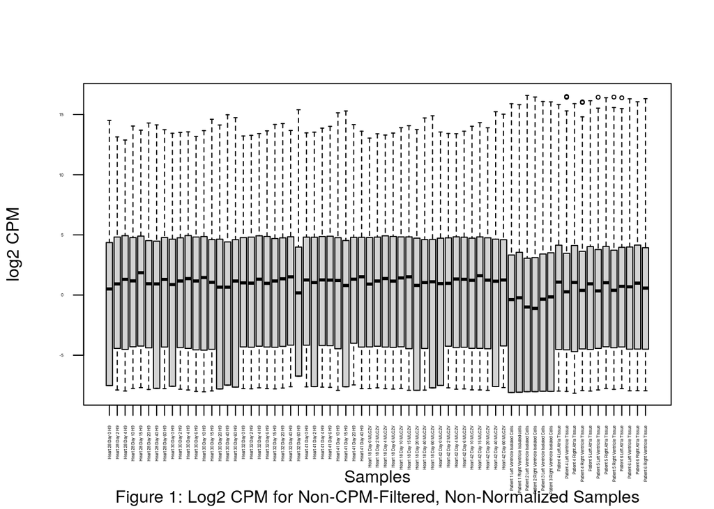

```r
bplot(pre_normalized_counts, "Figure 1: Log2 CPM for Non-CPM-Filtered, Non-Normalized Samples")
```

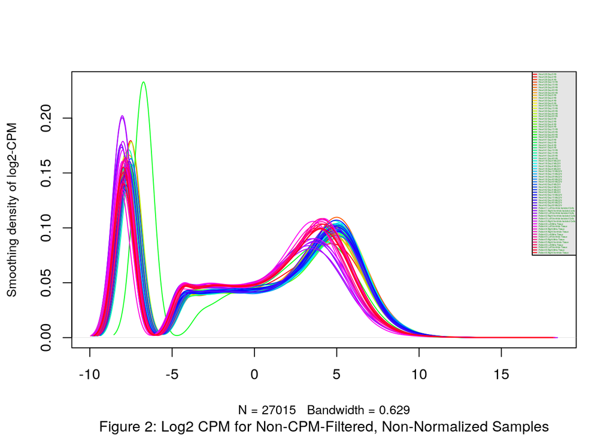

```r
dplot(pre_normalized_counts, "Figure 2: Log2 CPM for Non-CPM-Filtered, Non-Normalized Samples")
```

We only see a few potential outliers in the patient-derived samples, but those are subject to change upon filtering and normalization.

## CPM Filtering

Now, let’s filter our data. Since the minimum number of samples for a cell line is 2, we have two as our min.

```r
#minimal number of samples
min_num_samples <- 2
pre_normalized_counts_matrix <- as.matrix(pre_normalized_counts)
# get rid of low counts
keep = rowSums(log2(cpm(pre_normalized_counts_matrix+0.1)) > 1) > min_num_samples
filtered_counts_matrix = pre_normalized_counts_matrix[keep,]
```

Now, let’s visualize.

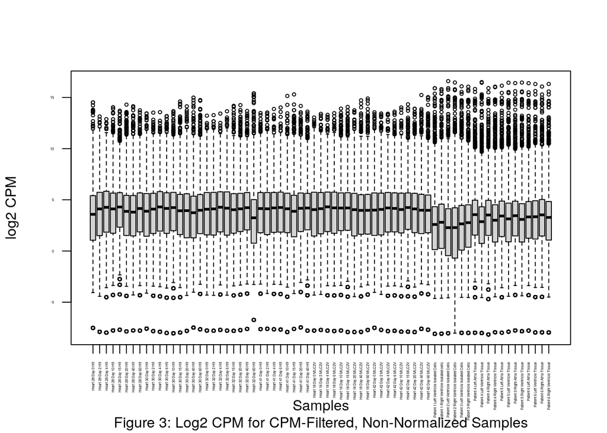

```r
bplot(filtered_counts_matrix, "Figure 3: Log2 CPM for CPM-Filtered, Non-Normalized Samples")
```

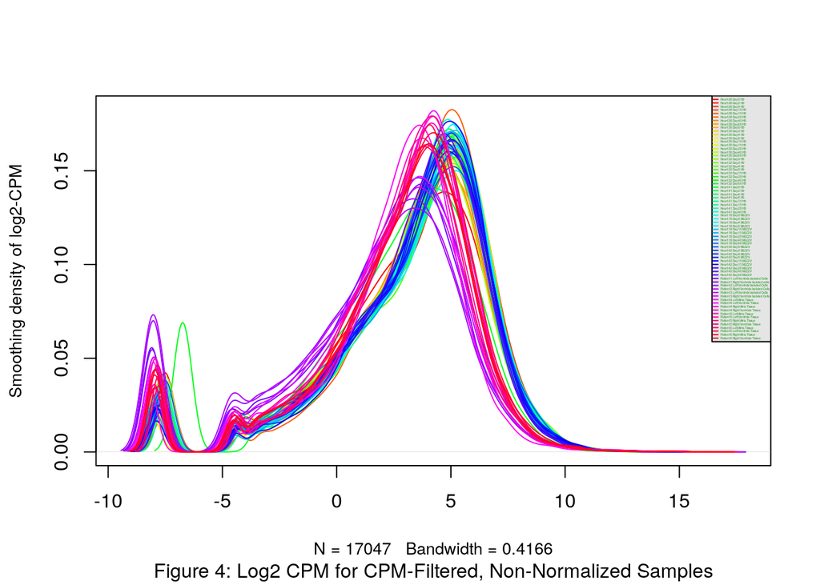

```r
dplot(filtered_counts_matrix, "Figure 4: Log2 CPM for CPM-Filtered, Non-Normalized Samples")
```

## Normalization using TMM

```r
d <- DGEList(counts=filtered_counts_matrix)
d <- calcNormFactors(d)
normalized_counts <- cpm(d)
```

The changes can then be re-examined.

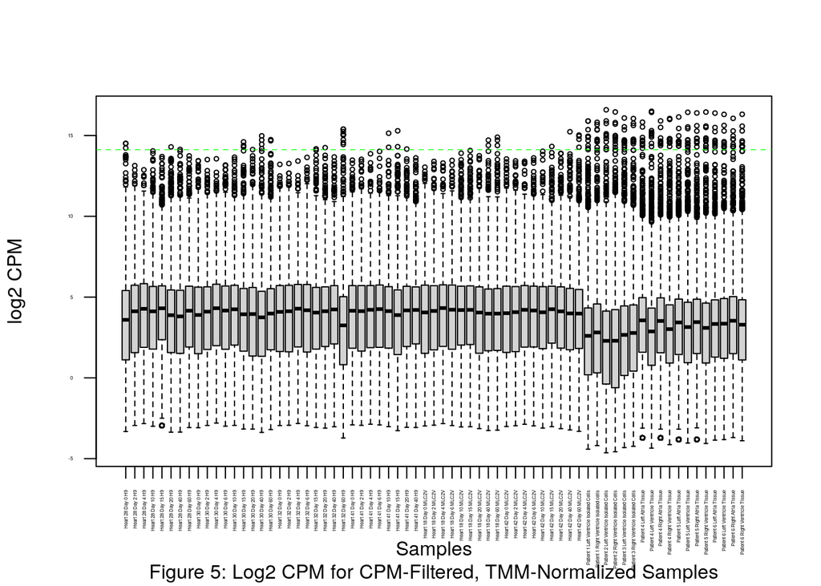

```r
bplot(normalized_counts, "Figure 5: Log2 CPM for CPM-Filtered, TMM-Normalized Samples")
```

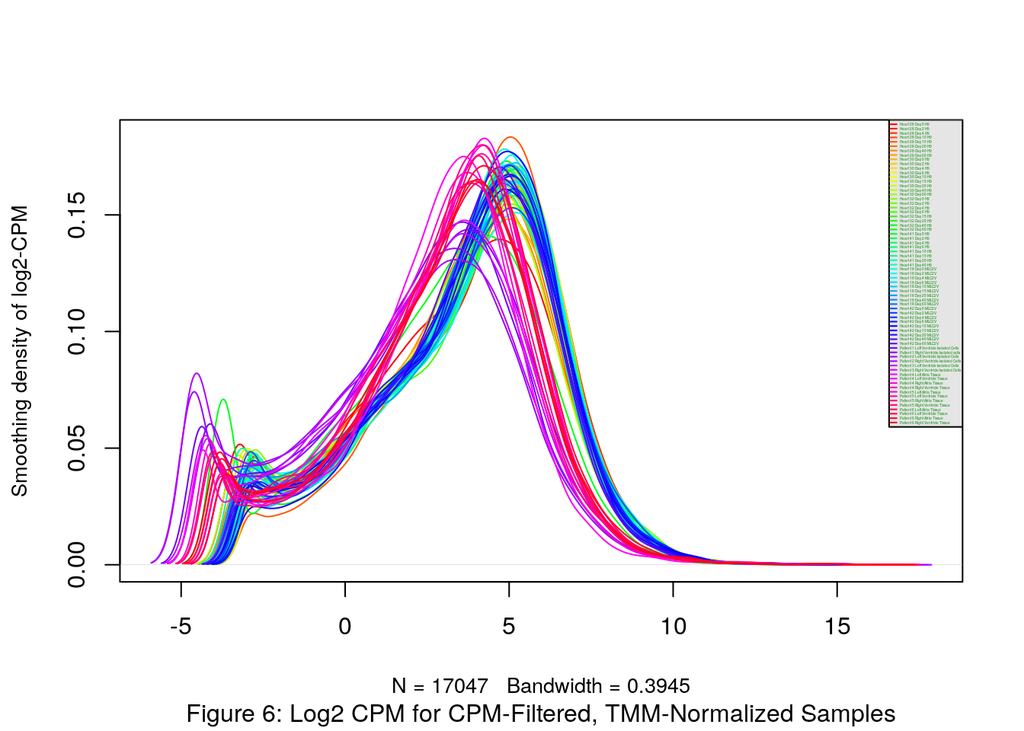

```r
dplot(normalized_counts, "Figure 6: Log2 CPM for CPM-Filtered, TMM-Normalized Samples")
```

## MDS Analysis

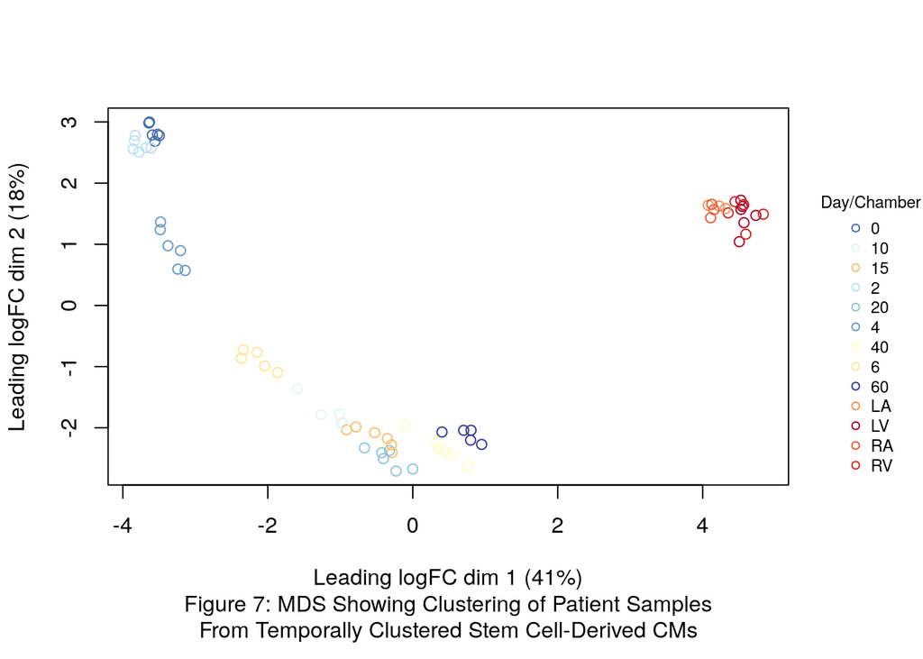

```r
par(xpd=T, mar=par()$mar+c(1.5,0,0,3))

n_colours <- length(c(unique(sample_info_1$day), unique(sample_info_2$chamber)))
palette <- sample(colorRampPalette(brewer.pal(n_colours, "RdYlBu"))(n_colours))

limma::plotMDS(d, pch = 1, col = palette[factor(c(sample_info_1$day, sample_info_2$chamber))])

mtext("Figure 7: MDS Showing Clustering of Patient Samples\nFrom Temporally Clustered Stem Cell-Derived CMs", side=1, line=5)

legend("bottomright",
       legend=levels(factor(c(sample_info_1$day, sample_info_2$chamber))),
       inset = c(-0.2,0),
       pch=c(1), col=palette,title="Day/Chamber",
       bty = 'n', cex = 0.75)
```

```r
par(mar=c(5, 4, 4, 2) + 0.1)
```

We can see that there is strong clustering of all the patient-derived samples, and there’s also temporal clustering of all the stem cell-derived CMs. This is a little surprising, since one would’ve expected the day 60 cells to better approximate the rest of the patient LV samples, both tissue and isolated CM.

## Dispersion

```r
d <- estimateDisp(d)
```

```
## Using classic mode.
```

### Biological Coefficient of Variation

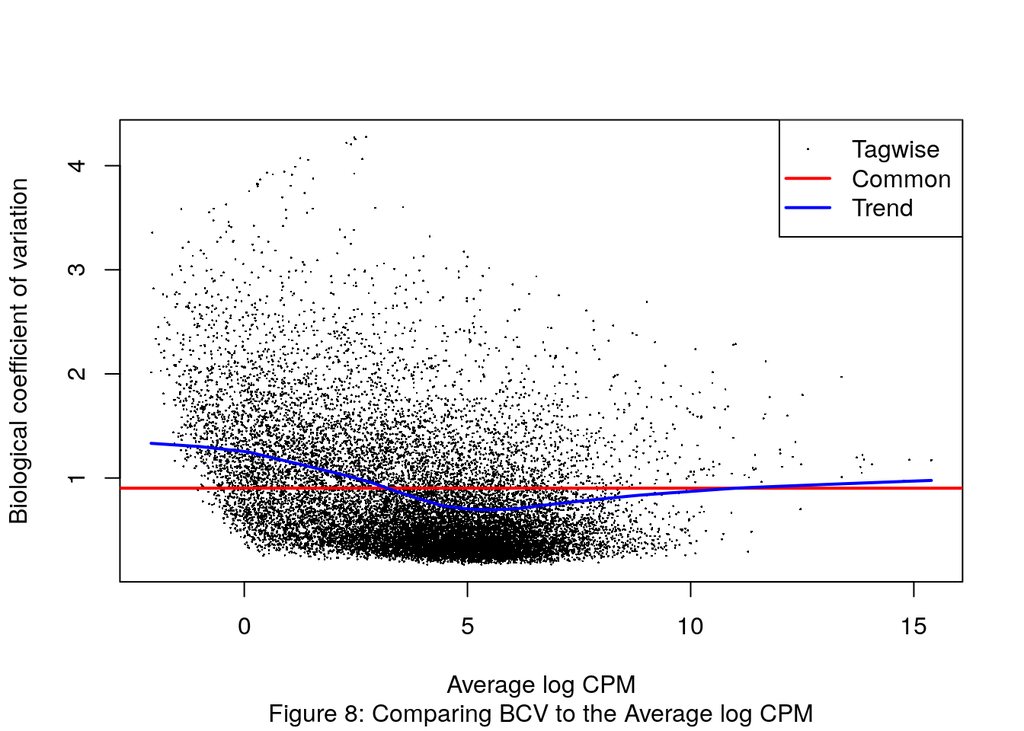

```r
plotBCV(d,col.tagwise = "black",col.common = "red", sub="Figure 8: Comparing BCV to the Average log CPM")
```

The BCV indicates that there is a high degree of variation in the dataset, suggesting that the dataset might show difficulty in trying ot find differentially expressed genes.

### Mean Variance

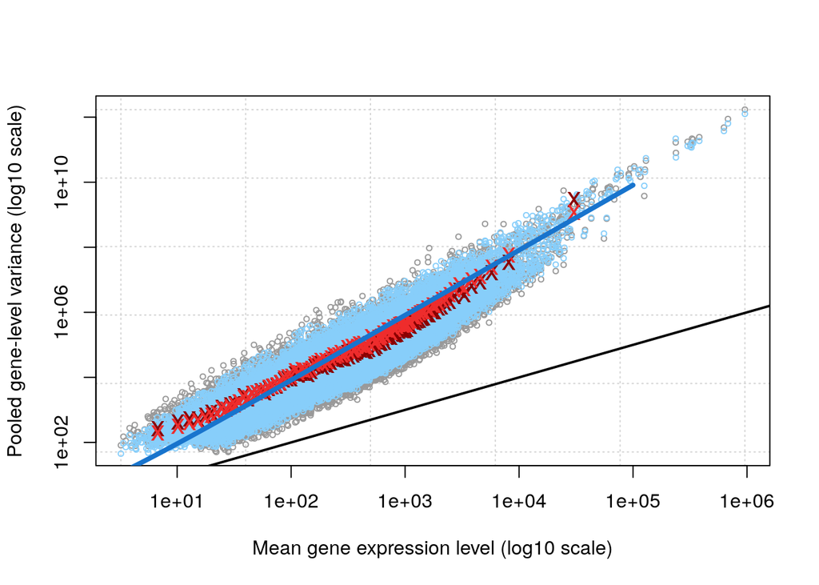

```r
plotMeanVar(d, show.raw.vars = TRUE, show.tagwise.vars = TRUE,
            NBline = TRUE, show.ave.raw.vars = TRUE,
            show.binned.common.disp.vars = TRUE)
mtext("Figure 9: Mean Variance Relationship Demonstrates that the data still follows a NB Distribution", side=1, line=5)
```

Since the data still follows a negative binomial distribution, it will still be suitable to analyze with edgeR in the next assignment. However, the high BCV values suggest that we will have some difficulties in finding differentially expressed genes.

# Answering the Final Questions

## What are the control and test conditions of the dataset?

Answered

## Why is the dataset of interest to you?

Answered

## Were there expression values that were not unique for specific genes? How did you handle these?

After HGNC mapping, there were no non-unique values, and as such, were not dealt with.

## Were there expression values that could not be mapped to current HUGO symbols?

There were, these values were filtered out if they has `NA` values for the HGNC symbol.

## How many outliers were removed?

No outliers were removed, inline with the authors’ original analysis.

## How did you handle replicates?

My dataset didn’t contain any technical replicates, only biological ones (`heart_x`, `patient_y`), and as a result let them be.

## What is the final coverage of your dataset?

```r
nrow(normalized_counts)/nrow(counts_data)
```

```
## [1] 0.4329287
```

We thus have a final coverage of around 43.3%.